# Phase 1A EFA - STARS & RMARS

Jenny Terry

10/06/2020

First, read in the cleaned, anonymised data.

```r
# read in anonymised data file
statanx_data <- readr::read_csv(here::here("data", "anon_data.csv"))
# check first few rows
head(statanx_data)
```

```
## # A tibble: 6 x 157
##   id    q4.1_1 q4.1_2 q4.1_3 q4.1_4 q4.1_5 q4.1_6 q4.1_7 q4.1_8 q4.1_9 q4.1_10
##   <chr>  <dbl>  <dbl>  <dbl>  <dbl>  <dbl>  <dbl>  <dbl>  <dbl>  <dbl>   <dbl>
## 1 jroWw      5      3      2      3      3      3      3      5      1       4
## 2 DMP8X      2      1      1      1      1      1      2      1      1       1
## 3 Jebht      3      3      2      3      4      3      5      5      1       5
## 4 1W4o3      4      2      4      5      4      3      5      5      3       5
## 5 fdzgn      4      3      3      2      3      2      4      4      1       3
## 6 Trng5      5      5      5      5      4      5      5      5      2       5
## # ... with 146 more variables: q4.1_11 <dbl>, q4.1_12 <dbl>, q4.1_13 <dbl>,
## #   q4.1_14 <dbl>, q4.1_15 <dbl>, q4.1_16 <dbl>, q4.1_17 <dbl>, q4.1_18 <dbl>,
## #   q4.1_19 <dbl>, q4.1_20 <dbl>, q4.1_21 <dbl>, q4.1_22 <dbl>, q4.1_23 <dbl>,
## #   q4.2_1 <dbl>, q4.2_2 <dbl>, q4.2_3 <dbl>, q4.2_4 <dbl>, q4.2_5 <dbl>,
## #   q4.2_6 <dbl>, q4.2_7 <dbl>, q4.2_8 <dbl>, q4.2_9 <dbl>, q4.2_10 <dbl>,
## #   q4.2_11 <dbl>, q4.2_12 <dbl>, q4.2_13 <dbl>, q4.2_14 <dbl>, q4.2_15 <dbl>,
## #   q4.2_16 <dbl>, q4.2_17 <dbl>, q4.2_18 <dbl>, q4.2_19 <dbl>, q4.2_20 <dbl>,
## #   q4.3_1 <dbl>, q4.3_2 <dbl>, q4.3_3 <dbl>, q4.3_4 <dbl>, q4.3_5 <dbl>,
## #   q4.3_6 <dbl>, q4.3_7 <dbl>, q4.3_8 <dbl>, q4.3_9 <dbl>, q4.3_10 <dbl>,
## #   q4.3_11 <dbl>, q4.3_12 <dbl>, q4.3_13 <dbl>, q4.3_14 <dbl>, q4.3_15 <dbl>,
## #   q4.3_16 <dbl>, q4.3_17 <dbl>, q4.3_18 <dbl>, q4.3_19 <dbl>, q4.3_20 <dbl>,
## #   q4.4_1 <dbl>, q4.4_2 <dbl>, q4.4_3 <dbl>, q4.4_4 <dbl>, q4.4_5 <dbl>,
## #   q4.4_6 <dbl>, q4.4_7 <dbl>, q4.4_8 <dbl>, q4.4_9 <dbl>, q4.4_10 <dbl>,
## #   q4.4_11 <dbl>, q4.4_12 <dbl>, q4.4_13 <dbl>, q4.4_14 <dbl>, q4.4_15 <dbl>,
## #   q4.4_16 <dbl>, q4.4_17 <dbl>, q4.4_18 <dbl>, q4.4_19 <dbl>, q5.1_1 <dbl>,
## #   q5.1_2 <dbl>, q5.1_3 <dbl>, q5.1_4 <dbl>, q5.1_5 <dbl>, q5.1_6 <dbl>,
## #   q5.1_7 <dbl>, q5.1_8 <dbl>, q5.1_9 <dbl>, q5.1_10 <dbl>, q5.1_11 <dbl>,
## #   q5.1_12 <dbl>, q5.1_13 <dbl>, q5.1_14 <dbl>, q5.1_15 <dbl>, q5.1_16 <dbl>,
## #   q5.1_17 <dbl>, q5.1_18 <dbl>, q5.1_19 <dbl>, q5.1_20 <dbl>, q5.1_21 <dbl>,
## #   q5.2_1 <dbl>, q5.2_2 <dbl>, q5.2_3 <dbl>, q5.2_4 <dbl>, q5.2_5 <dbl>,
## #   q5.2_6 <dbl>, q5.2_7 <dbl>, ...
```

The item names need to be converted to meaningful names for easier interpretation.

(I know this code is awful but I’ve already wasted too many hours trying to improve it so this will have to do for now!)

```r
statanx_data %<>%
  dplyr::rename(
    stars_test1 = q4.1_1,
    stars_int1 = q4.1_2,
    stars_help1 = q4.1_3,
    stars_test2 = q4.1_4,
    stars_int2 = q4.1_5,
    stars_int3 = q4.1_6,
    stars_int4 = q4.1_7,
    stars_test3 = q4.1_8,
    stars_int5 = q4.1_9,
    stars_test4 = q4.1_10,
    stars_int6 = q4.1_11,
    stars_int7 = q4.1_12,
    stars_test5 = q4.1_13,
    stars_int8 = q4.1_14,
    stars_test6 = q4.1_15,
    stars_help2 = q4.1_16,
    stars_int9 = q4.1_17,
    stars_int10 = q4.1_18,
    stars_help3 = q4.1_19,
    stars_int11 = q4.1_20,
    stars_test7 = q4.1_21,
    stars_test8 = q4.1_22,
    stars_help4 = q4.1_23,
    rmars_test1 = q4.3_1,
    rmars_test2 = q4.3_2,
    rmars_test3 = q4.3_3,
    rmars_test4 = q4.3_4,
    rmars_test5 = q4.3_5,
    rmars_test6 = q4.3_6,
    rmars_test7 = q4.3_7,
    rmars_test8 = q4.3_8,
    rmars_test9 = q4.3_9,
    rmars_test10 = q4.3_10,
    rmars_num1 = q4.3_11,
    rmars_num2 = q4.3_12,
    rmars_num3 = q4.3_13,
    rmars_num4 = q4.3_14,
    rmars_num5 = q4.3_15,
    rmars_course1 = q4.3_16,
    rmars_course2 = q4.3_17,
    rmars_course3 = q4.3_18,
    rmars_course4 = q4.3_19,
    rmars_course5 = q4.3_20
    )
```

For EFA, we will use a subset of the data that just contains all the items of the scales required for the analysis (STARS and RMARS for this phase).

```r
# prepare dataset for factor analysis
ph1a_fa_data <- dplyr::select(statanx_data, stars_test1:stars_help4, rmars_test1:rmars_course5)

# check dataset
head(ph1a_fa_data)
```

```
## # A tibble: 6 x 43
##   stars_test1 stars_int1 stars_help1 stars_test2 stars_int2 stars_int3
##         <dbl>      <dbl>       <dbl>       <dbl>      <dbl>      <dbl>
## 1           5          3           2           3          3          3
## 2           2          1           1           1          1          1
## 3           3          3           2           3          4          3
## 4           4          2           4           5          4          3
## 5           4          3           3           2          3          2
## 6           5          5           5           5          4          5
## # ... with 37 more variables: stars_int4 <dbl>, stars_test3 <dbl>,
## #   stars_int5 <dbl>, stars_test4 <dbl>, stars_int6 <dbl>, stars_int7 <dbl>,
## #   stars_test5 <dbl>, stars_int8 <dbl>, stars_test6 <dbl>, stars_help2 <dbl>,
## #   stars_int9 <dbl>, stars_int10 <dbl>, stars_help3 <dbl>, stars_int11 <dbl>,
## #   stars_test7 <dbl>, stars_test8 <dbl>, stars_help4 <dbl>, rmars_test1 <dbl>,
## #   rmars_test2 <dbl>, rmars_test3 <dbl>, rmars_test4 <dbl>, rmars_test5 <dbl>,
## #   rmars_test6 <dbl>, rmars_test7 <dbl>, rmars_test8 <dbl>, rmars_test9 <dbl>,
## #   rmars_test10 <dbl>, rmars_num1 <dbl>, rmars_num2 <dbl>, rmars_num3 <dbl>,
## #   rmars_num4 <dbl>, rmars_num5 <dbl>, rmars_course1 <dbl>,
## #   rmars_course2 <dbl>, rmars_course3 <dbl>, rmars_course4 <dbl>,
## #   rmars_course5 <dbl>
```

```r
# descriptive statistics
psych::describe(ph1a_fa_data)
```

```
##               vars   n mean   sd median trimmed  mad min max range  skew
## stars_test1      1 465 3.37 1.14      3    3.41 1.48   1   5     4 -0.25
## stars_int1       2 465 2.68 1.15      3    2.64 1.48   1   5     4  0.27
## stars_help1      3 465 3.04 1.32      3    3.05 1.48   1   5     4  0.03
## stars_test2      4 465 3.40 1.13      3    3.42 1.48   1   5     4 -0.15
## stars_int2       5 465 2.72 1.18      3    2.69 1.48   1   5     4  0.15
## stars_int3       6 465 2.36 1.08      2    2.29 1.48   1   5     4  0.47
## stars_int4       7 465 3.52 1.06      4    3.57 1.48   1   5     4 -0.31
## stars_test3      8 465 3.95 1.05      4    4.08 1.48   1   5     4 -0.75
## stars_int5       9 465 1.97 1.11      2    1.80 1.48   1   5     4  0.95
## stars_test4     10 465 3.70 1.15      4    3.80 1.48   1   5     4 -0.59
## stars_int6      11 465 2.60 1.20      2    2.54 1.48   1   5     4  0.29
## stars_int7      12 465 2.81 1.23      3    2.76 1.48   1   5     4  0.20
## stars_test5     13 465 3.38 1.08      3    3.40 1.48   1   5     4 -0.20
## stars_int8      14 465 2.57 1.18      2    2.51 1.48   1   5     4  0.34
## stars_test6     15 465 3.77 1.13      4    3.87 1.48   1   5     4 -0.63
## stars_help2     16 465 2.83 1.24      3    2.79 1.48   1   5     4  0.15
## stars_int9      17 465 2.08 1.12      2    1.93 1.48   1   5     4  0.85
## stars_int10     18 465 2.52 1.27      2    2.43 1.48   1   5     4  0.39
## stars_help3     19 465 2.83 1.24      3    2.78 1.48   1   5     4  0.19
## stars_int11     20 465 2.78 1.19      3    2.75 1.48   1   5     4  0.18
## stars_test7     21 465 2.74 1.28      3    2.68 1.48   1   5     4  0.23
## stars_test8     22 465 3.05 1.25      3    3.06 1.48   1   5     4  0.03
## stars_help4     23 465 2.63 1.21      2    2.57 1.48   1   5     4  0.33
## rmars_test1     24 465 2.94 1.09      3    2.93 1.48   1   5     4  0.08
## rmars_test2     25 465 3.57 1.17      4    3.64 1.48   1   5     4 -0.38
## rmars_test3     26 465 3.42 1.16      3    3.47 1.48   1   5     4 -0.29
## rmars_test4     27 465 4.01 1.04      4    4.16 1.48   1   5     4 -0.81
## rmars_test5     28 465 3.00 1.18      3    2.99 1.48   1   5     4  0.06
## rmars_test6     29 465 3.48 1.14      3    3.52 1.48   1   5     4 -0.23
## rmars_test7     30 465 3.77 1.09      4    3.86 1.48   1   5     4 -0.51
## rmars_test8     31 465 2.98 1.31      3    2.97 1.48   1   5     4  0.03
## rmars_test9     32 465 3.89 1.06      4    4.02 1.48   1   5     4 -0.71
## rmars_test10    33 465 3.82 1.12      4    3.93 1.48   1   5     4 -0.59
## rmars_num1      34 465 1.40 0.80      1    1.20 0.00   1   5     4  2.15
## rmars_num2      35 465 2.05 1.15      2    1.88 1.48   1   5     4  0.95
## rmars_num3      36 465 1.78 1.01      1    1.59 0.00   1   5     4  1.39
## rmars_num4      37 465 2.09 1.14      2    1.93 1.48   1   5     4  0.88
## rmars_num5      38 465 2.29 1.14      2    2.18 1.48   1   5     4  0.60
## rmars_course1   39 465 1.61 0.99      1    1.41 0.00   1   5     4  1.70
```

[output cut: 33 more lines]

```
## rmars_test6      -0.82 0.05
## rmars_test7      -0.61 0.05
## rmars_test8      -1.08 0.06
## rmars_test9      -0.27 0.05
## rmars_test10     -0.59 0.05
## rmars_num1        4.23 0.04
## rmars_num2       -0.03 0.05
## rmars_num3        1.45 0.05
## rmars_num4       -0.06 0.05
## rmars_num5       -0.45 0.05
## rmars_course1     2.32 0.05
## rmars_course2    -0.52 0.05
## rmars_course3    -0.99 0.06
## rmars_course4    -0.70 0.05
## rmars_course5    -0.28 0.05
```

We can obtain correlations using FIML (so that we don’t lose cases to pairwise deletion) by first calculating the covariance matrix (which will also be used for factor analysis) and then converting the covariances to correlations.

```r
# covariance matrix using fiml
ph1a_fa_cov <- psych::corFiml(ph1a_fa_data)
```

```r
# descriptive correlations
ph1a_fa_corr <- cov2cor(ph1a_fa_cov)
ph1a_fa_corr
```

```
##               stars_test1 stars_int1 stars_help1 stars_test2 stars_int2
## stars_test1     1.0000000  0.4253741   0.3661924   0.6182083  0.4400500
## stars_int1      0.4253741  1.0000000   0.3048519   0.4628089  0.5985490
## stars_help1     0.3661924  0.3048519   1.0000000   0.3775497  0.2929543
## stars_test2     0.6182083  0.4628089   0.3775497   1.0000000  0.4467233
## stars_int2      0.4400500  0.5985490   0.2929543   0.4467233  1.0000000
## stars_int3      0.4449568  0.6434612   0.3152557   0.4813335  0.5724501
## stars_int4      0.4816378  0.5104483   0.3621394   0.4557084  0.5297923
## stars_test3     0.5733768  0.3915560   0.3618821   0.5817245  0.4546079
## stars_int5      0.2234869  0.3887825   0.2573013   0.2279254  0.4194406
## stars_test4     0.4879688  0.3093353   0.2833849   0.4740485  0.3643490
## stars_int6      0.4072570  0.5771847   0.2652464   0.4066466  0.6241050
## stars_int7      0.4600585  0.5773622   0.4430574   0.5037779  0.5253378
## stars_test5     0.4495069  0.3859701   0.4011317   0.4095720  0.3702125
## stars_int8      0.3544474  0.4497407   0.2990227   0.3505034  0.5557876
## stars_test6     0.5786472  0.3284595   0.3130497   0.4839080  0.3688479
## stars_help2     0.3250526  0.3160263   0.8320634   0.3824422  0.3177694
## stars_int9      0.2652881  0.4627629   0.2120047   0.2591896  0.4386555
## stars_int10     0.4309794  0.5116906   0.3403676   0.4427850  0.5129462
## stars_help3     0.3171749  0.3514253   0.7255776   0.3946799  0.3348340
## stars_int11     0.4437052  0.6583961   0.3120395   0.5005792  0.6179276
## stars_test7     0.5670022  0.4822229   0.3407975   0.5338761  0.5044650
## stars_test8     0.4452595  0.3638306   0.3423989   0.3931807  0.3690932
## stars_help4     0.3441406  0.3879910   0.6584880   0.3721642  0.3451587
## rmars_test1     0.6205972  0.3675193   0.3239562   0.5345369  0.4226183
## rmars_test2     0.4120738  0.2319274   0.2731346   0.3779250  0.2838917
## rmars_test3     0.4486312  0.2282719   0.2711800   0.4127701  0.3142938
## rmars_test4     0.3983379  0.1759094   0.2196715   0.4127824  0.2578036
## rmars_test5     0.4843329  0.2649631   0.2758396   0.4468319  0.3291997
## rmars_test6     0.4843639  0.2366550   0.2683617   0.4432815  0.3015156
## rmars_test7     0.4244852  0.2409044   0.2491640   0.3900315  0.2879373
## rmars_test8     0.4678592  0.3580209   0.3469711   0.4697679  0.4138350
## rmars_test9     0.3614429  0.1870513   0.2705297   0.3170858  0.2232985
## rmars_test10    0.3657328  0.1965534   0.2523128   0.3732172  0.3003848
## rmars_num1      0.1779644  0.2838480   0.2321222   0.1671107  0.3056350
## rmars_num2      0.3341246  0.3187206   0.2078144   0.3012986  0.4216310
## rmars_num3      0.2888029  0.3062068   0.2028647   0.2439816  0.3955457
## rmars_num4      0.2968755  0.3731977   0.1977227   0.2859857  0.4185504
## rmars_num5      0.3432172  0.3824833   0.2076247   0.3013788  0.4411605
## rmars_course1   0.2332979  0.2615529   0.2661191   0.2607658  0.2773589
```

[output cut: 341 more lines]

```
## rmars_test6       0.5018837     0.3972471     0.4505942
## rmars_test7       0.4627968     0.3906963     0.4128054
## rmars_test8       0.6548619     0.5344861     0.5211667
## rmars_test9       0.3841492     0.3201524     0.3683487
## rmars_test10      0.4428234     0.3845734     0.4295654
## rmars_num1        0.2431884     0.2927467     0.2882037
## rmars_num2        0.5040064     0.4998255     0.4524359
## rmars_num3        0.4625149     0.5132235     0.4759042
## rmars_num4        0.4956554     0.5384811     0.5020510
## rmars_num5        0.4873099     0.5050495     0.4718881
## rmars_course1     0.4317228     0.4378449     0.4549545
## rmars_course2     0.5594172     0.6548872     0.5141500
## rmars_course3     1.0000000     0.5409805     0.5716902
## rmars_course4     0.5409805     1.0000000     0.4735768
## rmars_course5     0.5716902     0.4735768     1.0000000
```

The KMO test will provide an indication of sampling adequacy of each item. Scores > 0.5 are acceptable, the closer to 1 the better.

```r
# KMO test
psych::KMO(ph1a_fa_data)
```

```
## Kaiser-Meyer-Olkin factor adequacy
## Call: psych::KMO(r = ph1a_fa_data)
## Overall MSA =  0.96
## MSA for each item =
##   stars_test1    stars_int1   stars_help1   stars_test2    stars_int2
##          0.96          0.96          0.92          0.98          0.97
##    stars_int3    stars_int4   stars_test3    stars_int5   stars_test4
##          0.96          0.97          0.95          0.94          0.96
##    stars_int6    stars_int7   stars_test5    stars_int8   stars_test6
##          0.96          0.98          0.97          0.97          0.96
##   stars_help2    stars_int9   stars_int10   stars_help3   stars_int11
##          0.92          0.95          0.97          0.93          0.96
##   stars_test7   stars_test8   stars_help4   rmars_test1   rmars_test2
##          0.96          0.97          0.93          0.97          0.97
##   rmars_test3   rmars_test4   rmars_test5   rmars_test6   rmars_test7
##          0.97          0.96          0.96          0.96          0.97
##   rmars_test8   rmars_test9  rmars_test10    rmars_num1    rmars_num2
##          0.97          0.96          0.97          0.95          0.97
##    rmars_num3    rmars_num4    rmars_num5 rmars_course1 rmars_course2
##          0.95          0.96          0.96          0.95          0.97
## rmars_course3 rmars_course4 rmars_course5
##          0.97          0.97          0.97
```

A determinant above 0.00001 will indicate no problem with multicollinearity.

```r
# determinant
det(ph1a_fa_corr)
```

```
## [1] 0.00000000000002312209
```

```r
# **NOT IN PRE REG**
# tests the hypothesis that the correlation matrix is an identity matrix, we want it to be significant but it is dependent on sample size so with an n of 465, all it is telling us is that there isn't a MASSIVE problem
bartlett <- psych::cortest.bartlett(ph1a_fa_corr, n = 465)
```

The factors can now be extracted via parallel analysis using the following options:

fa.cov - covariance matrix fa = “fa” - show eigenvalues for a principal axis factor analysis fm = “pa” - change default method from minimum residual to principle axis factoring SMC = T - use squared multiple correlations to estimate communalities n.iter = 100 - use 100 iterations

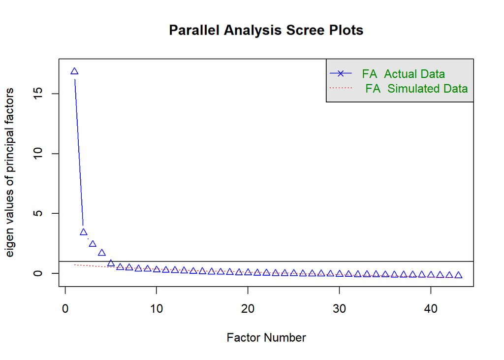

```
## Parallel analysis suggests that the number of factors =  6  and the number of components =  NA
```

```r
# test for the number of factors using parallel analysis
psych::fa.parallel(ph1a_fa_cov, n.obs = 465, fa = "fa", fm = "pa", SMC = T, n.iter = 100)
```

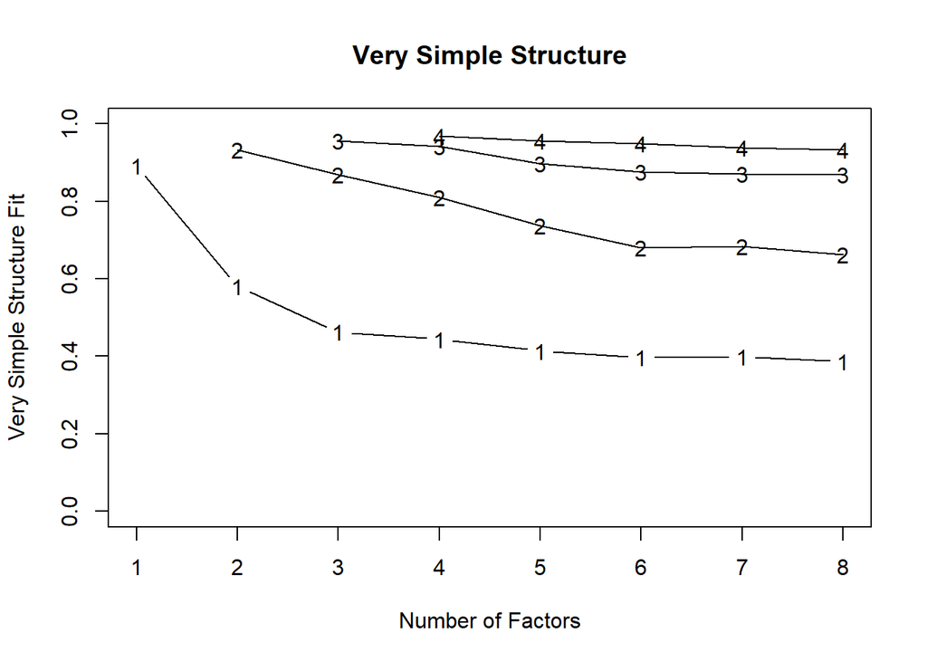

```
##
## Very Simple Structure
## Call: psych::vss(x = ph1a_fa_cov, fm = "pa", n.obs = 465)
## VSS complexity 1 achieves a maximimum of 0.89  with  1  factors
## VSS complexity 2 achieves a maximimum of 0.93  with  2  factors
##
## The Velicer MAP achieves a minimum of 0.01  with  5  factors
## BIC achieves a minimum of  -2795.63  with  5  factors
## Sample Size adjusted BIC achieves a minimum of  -728.65  with  8  factors
##
## Statistics by number of factors
##   vss1 vss2    map dof chisq
## 1 0.89 0.00 0.0304 860  5967
## 2 0.58 0.93 0.0183 818  4070
## 3 0.46 0.87 0.0138 777  2888
## 4 0.44 0.81 0.0088 737  1839
## 5 0.41 0.74 0.0084 698  1492
## 6 0.40 0.68 0.0090 660  1284
## 7 0.40 0.68 0.0094 623  1163
## 8 0.39 0.66 0.0100 587  1014
##                                                                                                                                                                                                                                                  prob
## 1 0.000000000000000000000000000000000000000000000000000000000000…
## 2 0.000000000000000000000000000000000000000000000000000000000000…
## 3 0.000000000000000000000000000000000000000000000000000000000000…
## 4 0.000000000000000000000000000000000000000000000000000000000000…
## 5 0.000000000000000000000000000000000000000000000000000000000011…
## 6 0.000000000000000000000000000000000000000001903237164824795498…
## 7 0.000000000000000000000000000000000042739435833393388079748387…
## 8 0.000000000000000000000000302509270079858195588891345284565659…
##   sqresid  fit RMSEA   BIC SABIC complex eChisq  SRMR eCRMS  eBIC
## 1    36.1 0.89 0.113   685  3415     1.0   9112 0.104 0.107  3830
## 2    22.1 0.93 0.092  -954  1642     1.5   4307 0.072 0.075  -717
## 3    14.6 0.96 0.076 -1884   582     1.8   1991 0.049 0.052 -2782
## 4    10.6 0.97 0.057 -2688  -349     1.9    834 0.032 0.035 -3693
## 5     9.3 0.97 0.049 -2796  -580     2.1    571 0.026 0.030 -3716
## 6     8.7 0.97 0.045 -2770  -675     2.2    467 0.024 0.028 -3586
## 7     8.0 0.98 0.043 -2664  -687     2.3    381 0.021 0.026 -3446
## 8     7.5 0.98 0.039 -2592  -729     2.4    323 0.020 0.024 -3283
```

```r
psych::vss(ph1a_fa_cov, n.obs = 465, fm = "pa")
```

The factor loadings after rotation will be interpreted and reported.

```r
# rotated factor solution
ph1a_fa_mod <- psych::fa(ph1a_fa_cov, n.obs = 465, nfactors = 5, fm = "pa", SMC = T, n.iter = 1, p = .05)
ph1a_fa_mod
```

```
## Factor Analysis using method =  pa
## Call: psych::fa(r = ph1a_fa_cov, nfactors = 5, n.obs = 465, n.iter = 1,
##     SMC = T, fm = "pa", p = 0.05)
## Standardized loadings (pattern matrix) based upon correlation matrix
##                 PA2   PA1   PA4   PA3   PA5   h2   u2 com
## stars_test1    0.32  0.35  0.05 -0.18  0.34 0.55 0.45 3.6
## stars_int1    -0.06  0.72  0.03  0.06  0.08 0.60 0.40 1.1
## stars_help1    0.05 -0.09  0.87 -0.04  0.04 0.73 0.27 1.0
## stars_test2    0.24  0.36  0.12 -0.20  0.35 0.54 0.46 3.6
## stars_int2     0.05  0.67 -0.01  0.17  0.03 0.60 0.40 1.1
## stars_int3    -0.07  0.68  0.07  0.12  0.10 0.61 0.39 1.2
## stars_int4     0.13  0.60  0.13 -0.10 -0.01 0.49 0.51 1.2
## stars_test3    0.70  0.31  0.09 -0.13 -0.07 0.67 0.33 1.5
## stars_int5    -0.06  0.36  0.13  0.32 -0.03 0.33 0.67 2.3
## stars_test4    0.65  0.29  0.05 -0.18 -0.02 0.57 0.43 1.6
## stars_int6     0.08  0.67  0.02  0.21 -0.06 0.59 0.41 1.2
## stars_int7    -0.04  0.49  0.23  0.06  0.23 0.59 0.41 1.9
## stars_test5    0.36  0.29  0.27 -0.02 -0.07 0.43 0.57 2.9
## stars_int8     0.08  0.49  0.09  0.18 -0.01 0.42 0.58 1.4
## stars_test6    0.72  0.26  0.02 -0.11 -0.04 0.64 0.36 1.3
## stars_help2    0.00 -0.06  0.93 -0.01  0.00 0.81 0.19 1.0
## stars_int9    -0.05  0.46  0.07  0.28 -0.03 0.36 0.64 1.7
## stars_int10   -0.02  0.50  0.17  0.11  0.14 0.51 0.49 1.5
## stars_help3    0.00  0.03  0.88 -0.01 -0.03 0.77 0.23 1.0
## stars_int11    0.01  0.69  0.01  0.09  0.16 0.65 0.35 1.1
## stars_test7    0.07  0.37  0.04 -0.10  0.54 0.61 0.39 1.9
## stars_test8    0.35  0.28  0.21  0.00 -0.02 0.40 0.60 2.6
## stars_help4   -0.06  0.10  0.80  0.03 -0.04 0.68 0.32 1.0
## rmars_test1    0.34  0.04  0.04  0.11  0.49 0.68 0.32 1.9
## rmars_test2    0.61 -0.05  0.05  0.16  0.10 0.54 0.46 1.2
## rmars_test3    0.70 -0.07  0.01  0.23  0.12 0.72 0.28 1.3
## rmars_test4    0.82 -0.12 -0.03  0.08  0.04 0.68 0.32 1.1
## rmars_test5    0.46  0.01  0.00  0.10  0.32 0.55 0.45 1.9
## rmars_test6    0.66 -0.07 -0.01  0.06  0.25 0.67 0.33 1.3
## rmars_test7    0.77 -0.08  0.01  0.09  0.09 0.69 0.31 1.1
## rmars_test8    0.17  0.06  0.04  0.15  0.55 0.62 0.38 1.4
## rmars_test9    0.68 -0.12  0.13  0.12 -0.05 0.50 0.50 1.2
## rmars_test10   0.65 -0.09  0.05  0.17  0.08 0.57 0.43 1.2
## rmars_num1    -0.13  0.20  0.15  0.46 -0.07 0.31 0.69 1.8
## rmars_num2     0.12  0.09  0.01  0.65  0.09 0.62 0.38 1.2
```

[output cut: 30 more lines]

```
## The root mean square of the residuals (RMSR) is  0.03
## The df corrected root mean square of the residuals is  0.03
##
## The harmonic number of observations is  465 with the empirical chi square  571.12  with prob <  1
## The total number of observations was  465  with Likelihood Chi Square =  1491.52  with prob <  0.000000000000000000000000000000000000000000000000000000000011
##
## Tucker Lewis Index of factoring reliability =  0.922
## RMSEA index =  0.049  and the 90 % confidence intervals are  0.046 0.053
## BIC =  -2795.63
## Fit based upon off diagonal values = 1
## Measures of factor score adequacy
##                                                    PA2  PA1  PA4  PA3  PA5
## Correlation of (regression) scores with factors   0.97 0.96 0.97 0.95 0.92
## Multiple R square of scores with factors          0.94 0.92 0.93 0.89 0.85
## Minimum correlation of possible factor scores     0.88 0.83 0.87 0.79 0.71
```

```r
# code from this Stack Exchange post: https://stackoverflow.com/questions/17371266/extracting-output-from-principal-function-in-psych-package-as-a-data-frame

getS3method("print","loadings")
```

```
## function (x, digits = 3L, cutoff = 0.1, sort = FALSE, ...)
## {
##     Lambda <- unclass(x)
##     p <- nrow(Lambda)
##     factors <- ncol(Lambda)
##     if (sort) {
##         mx <- max.col(abs(Lambda))
##         ind <- cbind(1L:p, mx)
##         mx[abs(Lambda[ind]) < 0.5] <- factors + 1
##         Lambda <- Lambda[order(mx, 1L:p), ]
##     }
##     cat("\nLoadings:\n")
##     fx <- setNames(format(round(Lambda, digits)), NULL)
##     nc <- nchar(fx[1L], type = "c")
##     fx[abs(Lambda) < cutoff] <- strrep(" ", nc)
##     print(fx, quote = FALSE, ...)
##     vx <- colSums(x^2)
##     varex <- rbind(`SS loadings` = vx)
##     if (is.null(attr(x, "covariance"))) {
##         varex <- rbind(varex, `Proportion Var` = vx/p)
##         if (factors > 1)
##             varex <- rbind(varex, `Cumulative Var` = cumsum(vx/p))
##     }
##     cat("\n")
##     print(round(varex, digits))
##     invisible(x)
## }
## <bytecode: 0x000000000cbc2f18>
## <environment: namespace:stats>
```

```r
printLoadings <- function (x, digits = 3, cutoff = 0.1, sort = FALSE, ...)
{
   Lambda <- unclass(x)
   p <- nrow(Lambda)
   factors <- ncol(Lambda)
   if (sort) {
      mx <- max.col(abs(Lambda))
      ind <- cbind(1L:p, mx)
      mx[abs(Lambda[ind]) < 0.5] <- factors + 1
      Lambda <- Lambda[order(mx, 1L:p), ]
   }
   cat("\nLoadings:\n")
   fx <- format(round(Lambda, digits))
   names(fx) <- NULL
   nc <- nchar(fx[1L], type = "c")
   fx[abs(Lambda) < cutoff] <- paste(rep(" ", nc), collapse = "")
   newx <- print(fx, quote = FALSE, ...)
   vx <- colSums(x^2)
   varex <- rbind(`SS loadings` = vx)
   if (is.null(attr(x, "covariance"))) {
      varex <- rbind(varex, `Proportion Var` = vx/p)
      if (factors > 1)
         varex <- rbind(varex, `Cumulative Var` = cumsum(vx/p))
   }
   cat("\n")
   print(round(varex, digits))
   invisible(newx)
}

ph1a_fa_loadings <- printLoadings(ph1a_fa_mod$loadings, digits = 2, cutoff = 0.4, sort = T)
```

```
##
## Loadings:
##               PA2   PA1   PA4   PA3   PA5
## stars_test3    0.70
## stars_test4    0.65
## stars_test6    0.72
## rmars_test2    0.61
## rmars_test3    0.70
## rmars_test4    0.82
## rmars_test6    0.66
## rmars_test7    0.77
## rmars_test9    0.68
## rmars_test10   0.65
## stars_int1           0.72
## stars_int2           0.67
## stars_int3           0.68
## stars_int4           0.60
## stars_int6           0.67
## stars_int11          0.69
## stars_help1                0.87
## stars_help2                0.93
## stars_help3                0.88
## stars_help4                0.80
## rmars_num2                       0.65
## rmars_num3                       0.76
## rmars_num4                       0.73
## rmars_num5                       0.66
## stars_test7                            0.54
## rmars_test8                            0.55
## rmars_course3                          0.66
## stars_test1
## stars_test2
## stars_int5
## stars_int7           0.49
## stars_test5
## stars_int8           0.49
## stars_int9           0.46
## stars_int10          0.50
## stars_test8
## rmars_test1                            0.49
## rmars_test5    0.46
## rmars_num1                       0.46
## rmars_course1
## rmars_course2
## rmars_course4
## rmars_course5
##
##                 PA2  PA1  PA4  PA3  PA5
## SS loadings    5.81 4.80 3.58 3.33 2.20
## Proportion Var 0.14 0.11 0.08 0.08 0.05
## Cumulative Var 0.14 0.25 0.33 0.41 0.46
```

```r
as.table(ph1a_fa_loadings)
```

```
##               PA2   PA1   PA4   PA3   PA5
## stars_test3    0.70
## stars_test4    0.65
## stars_test6    0.72
## rmars_test2    0.61
## rmars_test3    0.70
## rmars_test4    0.82
## rmars_test6    0.66
## rmars_test7    0.77
## rmars_test9    0.68
## rmars_test10   0.65
## stars_int1           0.72
## stars_int2           0.67
## stars_int3           0.68
## stars_int4           0.60
## stars_int6           0.67
## stars_int11          0.69
## stars_help1                0.87
## stars_help2                0.93
## stars_help3                0.88
## stars_help4                0.80
## rmars_num2                       0.65
## rmars_num3                       0.76
## rmars_num4                       0.73
## rmars_num5                       0.66
## stars_test7                            0.54
## rmars_test8                            0.55
## rmars_course3                          0.66
## stars_test1
## stars_test2
## stars_int5
## stars_int7           0.49
## stars_test5
## stars_int8           0.49
## stars_int9           0.46
## stars_int10          0.50
## stars_test8
## rmars_test1                            0.49
## rmars_test5    0.46
## rmars_num1                       0.46
## rmars_course1
## rmars_course2
## rmars_course4
## rmars_course5
```

```r
ph1a_fa_loadings %>%
  kableExtra::kable(
    col.names = c("Test\nAnxiety", "Interpretation\nAnxiety", "Fear of Asking\nfor Help", "Numerical\nCalculations", "Course/Studing\nAnxiety"),
    caption = "*Table 1* Factor Loadings",
    digits = 2

  ) %>%
  kableExtra::kable_styling()
```

*Table 1* Factor Loadings

|  | Test Anxiety | Interpretation Anxiety | Fear of Asking for Help | Numerical Calculations | Course/Studing Anxiety |
| --- | --- | --- | --- | --- | --- |
| stars_test3 | 0.70 |  |  |  |  |
| stars_test4 | 0.65 |  |  |  |  |
| stars_test6 | 0.72 |  |  |  |  |
| rmars_test2 | 0.61 |  |  |  |  |
| rmars_test3 | 0.70 |  |  |  |  |
| rmars_test4 | 0.82 |  |  |  |  |
| rmars_test6 | 0.66 |  |  |  |  |
| rmars_test7 | 0.77 |  |  |  |  |
| rmars_test9 | 0.68 |  |  |  |  |
| rmars_test10 | 0.65 |  |  |  |  |
| stars_int1 |  | 0.72 |  |  |  |
| stars_int2 |  | 0.67 |  |  |  |
| stars_int3 |  | 0.68 |  |  |  |
| stars_int4 |  | 0.60 |  |  |  |
| stars_int6 |  | 0.67 |  |  |  |
| stars_int11 |  | 0.69 |  |  |  |
| stars_help1 |  |  | 0.87 |  |  |
| stars_help2 |  |  | 0.93 |  |  |
| stars_help3 |  |  | 0.88 |  |  |
| stars_help4 |  |  | 0.80 |  |  |
| rmars_num2 |  |  |  | 0.65 |  |
| rmars_num3 |  |  |  | 0.76 |  |
| rmars_num4 |  |  |  | 0.73 |  |
| rmars_num5 |  |  |  | 0.66 |  |
| stars_test7 |  |  |  |  | 0.54 |
| rmars_test8 |  |  |  |  | 0.55 |
| rmars_course3 |  |  |  |  | 0.66 |
| stars_test1 |  |  |  |  |  |
| stars_test2 |  |  |  |  |  |
| stars_int5 |  |  |  |  |  |
| stars_int7 |  | 0.49 |  |  |  |
| stars_test5 |  |  |  |  |  |
| stars_int8 |  | 0.49 |  |  |  |
| stars_int9 |  | 0.46 |  |  |  |
| stars_int10 |  | 0.50 |  |  |  |
| stars_test8 |  |  |  |  |  |
| rmars_test1 |  |  |  |  | 0.49 |
| rmars_test5 | 0.46 |  |  |  |  |
| rmars_num1 |  |  |  | 0.46 |  |
| rmars_course1 |  |  |  |  |  |
| rmars_course2 |  |  |  |  |  |
| rmars_course4 |  |  |  |  |  |
| rmars_course5 |  |  |  |  |  |

Check that most residuals are lower than 0.05.

```r
# check residuals
residuals <- psych::factor.residuals(ph1a_fa_corr, ph1a_fa_mod)
residuals %>% dplyr::as_tibble(., rownames = "item")
```

```
## # A tibble: 43 x 44
##    item  stars_test1 stars_int1 stars_help1 stars_test2 stars_int2 stars_int3
##    <chr>       <dbl>      <dbl>       <dbl>       <dbl>      <dbl>      <dbl>
##  1 star~    0.447      -0.0146      0.0260      0.0742    -0.00960  -0.000497
##  2 star~   -0.0146      0.396       0.0119      0.0103     0.00766   0.0395
##  3 star~    0.0260      0.0119      0.273       0.00120    0.0175   -0.00631
##  4 star~    0.0742      0.0103      0.00120     0.458     -0.00581   0.0231
##  5 star~   -0.00960     0.00766     0.0175     -0.00581    0.402    -0.0231
##  6 star~   -0.000497    0.0395     -0.00631     0.0231    -0.0231    0.390
##  7 star~    0.0420     -0.00641     0.0236      0.00656    0.0258   -0.0425
##  8 star~    0.0325      0.00138     0.0124      0.0654     0.0248   -0.0368
##  9 star~   -0.0354     -0.00886     0.00198    -0.0395     0.00977   0.0155
## 10 star~   -0.0158     -0.0381     -0.0196     -0.00598   -0.0165   -0.00926
## # ... with 33 more rows, and 37 more variables: stars_int4 <dbl>,
## #   stars_test3 <dbl>, stars_int5 <dbl>, stars_test4 <dbl>, stars_int6 <dbl>,
## #   stars_int7 <dbl>, stars_test5 <dbl>, stars_int8 <dbl>, stars_test6 <dbl>,
## #   stars_help2 <dbl>, stars_int9 <dbl>, stars_int10 <dbl>, stars_help3 <dbl>,
## #   stars_int11 <dbl>, stars_test7 <dbl>, stars_test8 <dbl>, stars_help4 <dbl>,
## #   rmars_test1 <dbl>, rmars_test2 <dbl>, rmars_test3 <dbl>, rmars_test4 <dbl>,
## #   rmars_test5 <dbl>, rmars_test6 <dbl>, rmars_test7 <dbl>, rmars_test8 <dbl>,
## #   rmars_test9 <dbl>, rmars_test10 <dbl>, rmars_num1 <dbl>, rmars_num2 <dbl>,
## #   rmars_num3 <dbl>, rmars_num4 <dbl>, rmars_num5 <dbl>, rmars_course1 <dbl>,
## #   rmars_course2 <dbl>, rmars_course3 <dbl>, rmars_course4 <dbl>,
## #   rmars_course5 <dbl>
```

Plot factor solution.

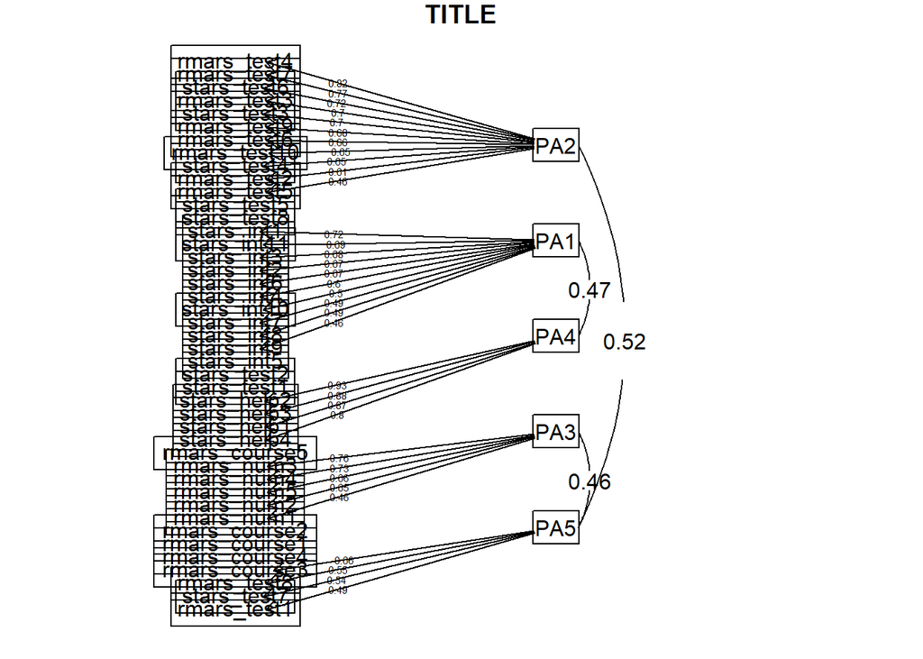

```r
# draw path diagram of factor solution
psych::fa.diagram(ph1a_fa_mod, cut = 0.4, main = "TITLE", rsize = 2, digits = 2)
```

```r
ph1a_fa_mod
```

```
## Factor Analysis using method =  pa
## Call: psych::fa(r = ph1a_fa_cov, nfactors = 5, n.obs = 465, n.iter = 1,
##     SMC = T, fm = "pa", p = 0.05)
## Standardized loadings (pattern matrix) based upon correlation matrix
##                 PA2   PA1   PA4   PA3   PA5   h2   u2 com
## stars_test1    0.32  0.35  0.05 -0.18  0.34 0.55 0.45 3.6
## stars_int1    -0.06  0.72  0.03  0.06  0.08 0.60 0.40 1.1
## stars_help1    0.05 -0.09  0.87 -0.04  0.04 0.73 0.27 1.0
## stars_test2    0.24  0.36  0.12 -0.20  0.35 0.54 0.46 3.6
## stars_int2     0.05  0.67 -0.01  0.17  0.03 0.60 0.40 1.1
## stars_int3    -0.07  0.68  0.07  0.12  0.10 0.61 0.39 1.2
## stars_int4     0.13  0.60  0.13 -0.10 -0.01 0.49 0.51 1.2
## stars_test3    0.70  0.31  0.09 -0.13 -0.07 0.67 0.33 1.5
## stars_int5    -0.06  0.36  0.13  0.32 -0.03 0.33 0.67 2.3
## stars_test4    0.65  0.29  0.05 -0.18 -0.02 0.57 0.43 1.6
## stars_int6     0.08  0.67  0.02  0.21 -0.06 0.59 0.41 1.2
## stars_int7    -0.04  0.49  0.23  0.06  0.23 0.59 0.41 1.9
## stars_test5    0.36  0.29  0.27 -0.02 -0.07 0.43 0.57 2.9
## stars_int8     0.08  0.49  0.09  0.18 -0.01 0.42 0.58 1.4
## stars_test6    0.72  0.26  0.02 -0.11 -0.04 0.64 0.36 1.3
## stars_help2    0.00 -0.06  0.93 -0.01  0.00 0.81 0.19 1.0
## stars_int9    -0.05  0.46  0.07  0.28 -0.03 0.36 0.64 1.7
## stars_int10   -0.02  0.50  0.17  0.11  0.14 0.51 0.49 1.5
## stars_help3    0.00  0.03  0.88 -0.01 -0.03 0.77 0.23 1.0
## stars_int11    0.01  0.69  0.01  0.09  0.16 0.65 0.35 1.1
## stars_test7    0.07  0.37  0.04 -0.10  0.54 0.61 0.39 1.9
## stars_test8    0.35  0.28  0.21  0.00 -0.02 0.40 0.60 2.6
## stars_help4   -0.06  0.10  0.80  0.03 -0.04 0.68 0.32 1.0
## rmars_test1    0.34  0.04  0.04  0.11  0.49 0.68 0.32 1.9
## rmars_test2    0.61 -0.05  0.05  0.16  0.10 0.54 0.46 1.2
## rmars_test3    0.70 -0.07  0.01  0.23  0.12 0.72 0.28 1.3
## rmars_test4    0.82 -0.12 -0.03  0.08  0.04 0.68 0.32 1.1
## rmars_test5    0.46  0.01  0.00  0.10  0.32 0.55 0.45 1.9
## rmars_test6    0.66 -0.07 -0.01  0.06  0.25 0.67 0.33 1.3
## rmars_test7    0.77 -0.08  0.01  0.09  0.09 0.69 0.31 1.1
## rmars_test8    0.17  0.06  0.04  0.15  0.55 0.62 0.38 1.4
## rmars_test9    0.68 -0.12  0.13  0.12 -0.05 0.50 0.50 1.2
## rmars_test10   0.65 -0.09  0.05  0.17  0.08 0.57 0.43 1.2
## rmars_num1    -0.13  0.20  0.15  0.46 -0.07 0.31 0.69 1.8
## rmars_num2     0.12  0.09  0.01  0.65  0.09 0.62 0.38 1.2
```

[output cut: 30 more lines]

```
## The root mean square of the residuals (RMSR) is  0.03
## The df corrected root mean square of the residuals is  0.03
##
## The harmonic number of observations is  465 with the empirical chi square  571.12  with prob <  1
## The total number of observations was  465  with Likelihood Chi Square =  1491.52  with prob <  0.000000000000000000000000000000000000000000000000000000000011
##
## Tucker Lewis Index of factoring reliability =  0.922
## RMSEA index =  0.049  and the 90 % confidence intervals are  0.046 0.053
## BIC =  -2795.63
## Fit based upon off diagonal values = 1
## Measures of factor score adequacy
##                                                    PA2  PA1  PA4  PA3  PA5
## Correlation of (regression) scores with factors   0.97 0.96 0.97 0.95 0.92
## Multiple R square of scores with factors          0.94 0.92 0.93 0.89 0.85
## Minimum correlation of possible factor scores     0.88 0.83 0.87 0.79 0.71
```

```r
print(ph1a_fa_mod)
```

```
## Factor Analysis using method =  pa
## Call: psych::fa(r = ph1a_fa_cov, nfactors = 5, n.obs = 465, n.iter = 1,
##     SMC = T, fm = "pa", p = 0.05)
## Standardized loadings (pattern matrix) based upon correlation matrix
##                 PA2   PA1   PA4   PA3   PA5   h2   u2 com
## stars_test1    0.32  0.35  0.05 -0.18  0.34 0.55 0.45 3.6
## stars_int1    -0.06  0.72  0.03  0.06  0.08 0.60 0.40 1.1
## stars_help1    0.05 -0.09  0.87 -0.04  0.04 0.73 0.27 1.0
## stars_test2    0.24  0.36  0.12 -0.20  0.35 0.54 0.46 3.6
## stars_int2     0.05  0.67 -0.01  0.17  0.03 0.60 0.40 1.1
## stars_int3    -0.07  0.68  0.07  0.12  0.10 0.61 0.39 1.2
## stars_int4     0.13  0.60  0.13 -0.10 -0.01 0.49 0.51 1.2
## stars_test3    0.70  0.31  0.09 -0.13 -0.07 0.67 0.33 1.5
## stars_int5    -0.06  0.36  0.13  0.32 -0.03 0.33 0.67 2.3
## stars_test4    0.65  0.29  0.05 -0.18 -0.02 0.57 0.43 1.6
## stars_int6     0.08  0.67  0.02  0.21 -0.06 0.59 0.41 1.2
## stars_int7    -0.04  0.49  0.23  0.06  0.23 0.59 0.41 1.9
## stars_test5    0.36  0.29  0.27 -0.02 -0.07 0.43 0.57 2.9
## stars_int8     0.08  0.49  0.09  0.18 -0.01 0.42 0.58 1.4
## stars_test6    0.72  0.26  0.02 -0.11 -0.04 0.64 0.36 1.3
## stars_help2    0.00 -0.06  0.93 -0.01  0.00 0.81 0.19 1.0
## stars_int9    -0.05  0.46  0.07  0.28 -0.03 0.36 0.64 1.7
## stars_int10   -0.02  0.50  0.17  0.11  0.14 0.51 0.49 1.5
## stars_help3    0.00  0.03  0.88 -0.01 -0.03 0.77 0.23 1.0
## stars_int11    0.01  0.69  0.01  0.09  0.16 0.65 0.35 1.1
## stars_test7    0.07  0.37  0.04 -0.10  0.54 0.61 0.39 1.9
## stars_test8    0.35  0.28  0.21  0.00 -0.02 0.40 0.60 2.6
## stars_help4   -0.06  0.10  0.80  0.03 -0.04 0.68 0.32 1.0
## rmars_test1    0.34  0.04  0.04  0.11  0.49 0.68 0.32 1.9
## rmars_test2    0.61 -0.05  0.05  0.16  0.10 0.54 0.46 1.2
## rmars_test3    0.70 -0.07  0.01  0.23  0.12 0.72 0.28 1.3
## rmars_test4    0.82 -0.12 -0.03  0.08  0.04 0.68 0.32 1.1
## rmars_test5    0.46  0.01  0.00  0.10  0.32 0.55 0.45 1.9
## rmars_test6    0.66 -0.07 -0.01  0.06  0.25 0.67 0.33 1.3
## rmars_test7    0.77 -0.08  0.01  0.09  0.09 0.69 0.31 1.1
## rmars_test8    0.17  0.06  0.04  0.15  0.55 0.62 0.38 1.4
## rmars_test9    0.68 -0.12  0.13  0.12 -0.05 0.50 0.50 1.2
## rmars_test10   0.65 -0.09  0.05  0.17  0.08 0.57 0.43 1.2
## rmars_num1    -0.13  0.20  0.15  0.46 -0.07 0.31 0.69 1.8
## rmars_num2     0.12  0.09  0.01  0.65  0.09 0.62 0.38 1.2
```

[output cut: 30 more lines]

```
## The root mean square of the residuals (RMSR) is  0.03
## The df corrected root mean square of the residuals is  0.03
##
## The harmonic number of observations is  465 with the empirical chi square  571.12  with prob <  1
## The total number of observations was  465  with Likelihood Chi Square =  1491.52  with prob <  0.000000000000000000000000000000000000000000000000000000000011
##
## Tucker Lewis Index of factoring reliability =  0.922
## RMSEA index =  0.049  and the 90 % confidence intervals are  0.046 0.053
## BIC =  -2795.63
## Fit based upon off diagonal values = 1
## Measures of factor score adequacy
##                                                    PA2  PA1  PA4  PA3  PA5
## Correlation of (regression) scores with factors   0.97 0.96 0.97 0.95 0.92
## Multiple R square of scores with factors          0.94 0.92 0.93 0.89 0.85
## Minimum correlation of possible factor scores     0.88 0.83 0.87 0.79 0.71
```

Finally, calculate reliability of retained factors.

```r
# create dataframes containing raw scores for each factor, e.g:
test_anx <- dplyr::select(ph1a_fa_data, c("rmars_test4", "rmars_test7", "stars_test6", "stars_test3", "rmars_test3", "rmars_test9", "rmars_test6", "rmars_test10", "stars_test4", "rmars_test2", "rmars_test5"))

int_anx <- dplyr::select(ph1a_fa_data, c("stars_int1", "stars_int11", "stars_int3", "stars_int2", "stars_int6", "stars_int4", "stars_int10", "stars_int7", "stars_int8", "stars_int9"))

help_anx <- dplyr::select(ph1a_fa_data, c("stars_help2", "stars_help3", "stars_help1", "stars_help4"))

num_calc_anx <- dplyr::select(ph1a_fa_data, c("rmars_num3", "rmars_num4", "rmars_num5", "rmars_num2", "rmars_num1"))

course_anx <- dplyr::select(ph1a_fa_data, c("rmars_course3", "rmars_test8", "stars_test7", "rmars_test1"))
```

```r
# calculate the point estimate and confidence interval for omega reliability coefficient
MBESS::ci.reliability(test_anx, type = "omega", conf.level = 0.95, interval.type = "bca", B = 1000)
```

```
## $est
## [1] 0.9362582
##
## $se
## [1] 0.004889596
##
## $ci.lower
## [1] 0.9259728
##
## $ci.upper
## [1] 0.9447434
##
## $conf.level
## [1] 0.95
##
## $type
## [1] "omega"
##
## $interval.type
## [1] "bca bootstrap"
```

```r
MBESS::ci.reliability(int_anx, type = "omega", conf.level = 0.95, interval.type = "bca", B = 1000)
```

```
## $est
## [1] 0.9170605
##
## $se
## [1] 0.006224531
##
## $ci.lower
## [1] 0.9025037
##
## $ci.upper
## [1] 0.92803
##
## $conf.level
## [1] 0.95
##
## $type
## [1] "omega"
##
## $interval.type
## [1] "bca bootstrap"
```

```r
MBESS::ci.reliability(help_anx, type = "omega", conf.level = 0.95, interval.type = "bca", B = 1000)
```

```
## $est
## [1] 0.9216283
##
## $se
## [1] 0.006936085
##
## $ci.lower
## [1] 0.9069735
##
## $ci.upper
## [1] 0.9336493
##
## $conf.level
## [1] 0.95
##
## $type
## [1] "omega"
##
## $interval.type
## [1] "bca bootstrap"
```

```r
MBESS::ci.reliability(num_calc_anx, type = "omega", conf.level = 0.95, interval.type = "bca", B = 1000)
```

```
## $est
## [1] 0.8904499
##
## $se
## [1] 0.009770608
##
## $ci.lower
## [1] 0.8687056
##
## $ci.upper
## [1] 0.9082534
##
## $conf.level
## [1] 0.95
##
## $type
## [1] "omega"
##
## $interval.type
## [1] "bca bootstrap"
```

```r
MBESS::ci.reliability(course_anx, type = "omega", conf.level = 0.95, interval.type = "bca", B = 1000)
```

```
## $est
## [1] 0.8652387
##
## $se
## [1] 0.01178905
##
## $ci.lower
## [1] 0.8397751
##
## $ci.upper
## [1] 0.8867881
##
## $conf.level
## [1] 0.95
##
## $type
## [1] "omega"
##
## $interval.type
## [1] "bca bootstrap"
```